# GDP and life expectancy globally between countries over the years

PfE class 2026

2026-06-16

Thea von Sydow 2882066

# Title Page

Group members:Egemen Çivici, Eunji Hong, EnChi Hsu(Brian), Rares Raţiu, Barna Sebestyén, Thea Von Sydow

Tutorial group: 3.6

Tutorial lecturer: Chantal Schouwenaar

# Part 1 - Identify a Social Problem

## 1.1 Describe the Social Problem

Differences in life expectancy between countries are one of the clearest forms of global inequality. A child born in a high-income country can expect to live around fifteen to twenty years longer than a child born in a low-income country, and this gap has persisted for decades. The classic explanation links population health to national income: (Preston, 1975) showed that life expectancy rises steeply with GDP per capita at low income levels and flattens among richer countries, which implies that economic growth buys the most health where countries are poorest (Deaton, 2003)]. A key lever for policy is therefore knowing how tightly health follows income, because that determines whether health gaps should be fought with economic development, with health spending, or both.

What is less well established is how this relationship behaves during a global shock. The COVID-19 pandemic caused the first worldwide drop in life expectancy in decades, and the losses were very unequal between countries (Schöley, 2022), yet income alone did not fully predict who lost the most. In this report we quantify the relationship between GDP per capita and life expectancy for ten countries across all income levels between 2019 and 2023, and we examine how life expectancy changed around the 2020 outbreak of the COVID-19 pandemic.

# Part 2 - Data Sourcing<

## 2.2 Provide a short summary of the dataset(s)

This analysis uses two datasets from the World Bank’s World Development Indicators. Both were downloaded as CSV files, and each can also be identified by its WDI indicator code.

The first dataset reports GDP per capita, PPP, in constant international dollars (indicator NY.GDP.PCAP.PP.KD). Measuring income in purchasing power parity terms and holding prices constant means GDP per capita can be compared fairly between countries and across years, without being thrown off by exchange rate swings or inflation.

The second dataset reports life expectancy at birth, total, in years (indicator SP.DYN.LE00.IN). This is the average number of years a newborn would live if the mortality patterns of that year stayed the same throughout its life.

In their raw form, each file has one row per economy (around 260 countries and regional aggregates) and one column per year going back to 1960, plus identifier columns for country name, country code, and indicator name and code. For this report we narrowed the data down to ten countries that cover a range of income levels: the United States, the Netherlands, Germany, Japan, China, India, Brazil, South Africa, Nigeria, and Australia. We also limited it to the five years from 2019 to 2023, which is the window around the COVID-19 outbreak. After reshaping both files into long format and merging them on country and year, the final working dataset (combined_data) has 50 observations (10 countries across 5 years) and five columns: country, country_code, year, gdp_per_capita in constant international dollars, and life_expectancy in years.

# Part 3 - Our findings

## 3.1 Describe the variables

After cleaning and merging the datasets, the final dataset contains information on 10 selected countries from 2019 to 2023. The main variables are country, year, GDP per capita, and life expectancy. In addition to these original variables, we created two new categorical variables to support our analysis. The variable development_group separates countries into developed and developing countries, which is used for the sub-population comparison. The variable covid_period divides the years into pre-COVID, COVID period, and post-COVID recovery, which is used to analyse the effect of the COVID-19 period on life expectancy.

## 3.2 Generate necessary variables

Variable 1 To add analytical value to the dataset, we created two new categorical variables. First, we constructed development_group, which classifies the ten selected countries into developed and developing countries. This variable was used in the sub-population analysis to compare GDP per capita and life expectancy across different development groups.

Variable 2 Second, we created covid_period, which classifies the years into pre-COVID, COVID period, and post-COVID recovery. This variable was used to analyse how average life expectancy changed before, during, and after the COVID-19 pandemic.

## 3.3 Visualize temporal variation

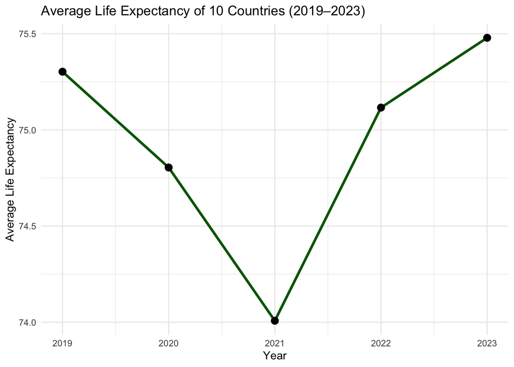

## 3.4 Visualize spatial variation

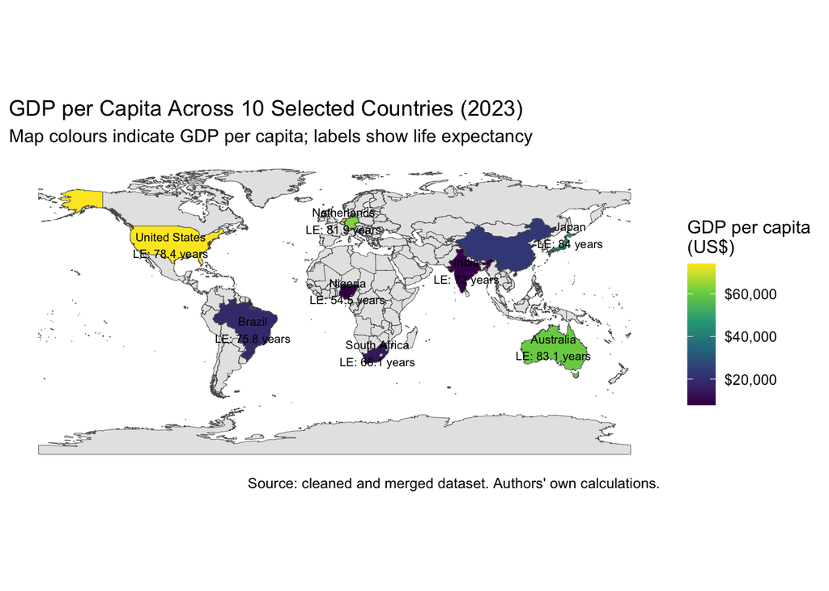

## 3.5 Visualize sub-population variation

The graph highlights a clear difference between developed and developing countries. Developed countries generally show both higher GDP per capita and higher life expectancy, whereas developing countries tend to have lower values for both indicators. This pattern suggests that higher levels of economic development are associated with better health outcomes and longer lives.

```
## Rows: 50
## Columns: 5
## $ country         <chr> "Australia", "Australia", "Australia", "Australia", "A…
## $ country_code    <chr> "AUS", "AUS", "AUS", "AUS", "AUS", "BRA", "BRA", "BRA"…
## $ year            <dbl> 2019, 2020, 2021, 2022, 2023, 2019, 2020, 2021, 2022, …
## $ gdp_per_capita  <dbl> 58048.619, 57260.465, 58327.415, 60029.133, 60684.960,…
## $ life_expectancy <dbl> 82.90000, 83.20000, 83.30000, 83.20000, 83.05122, 75.8…
```

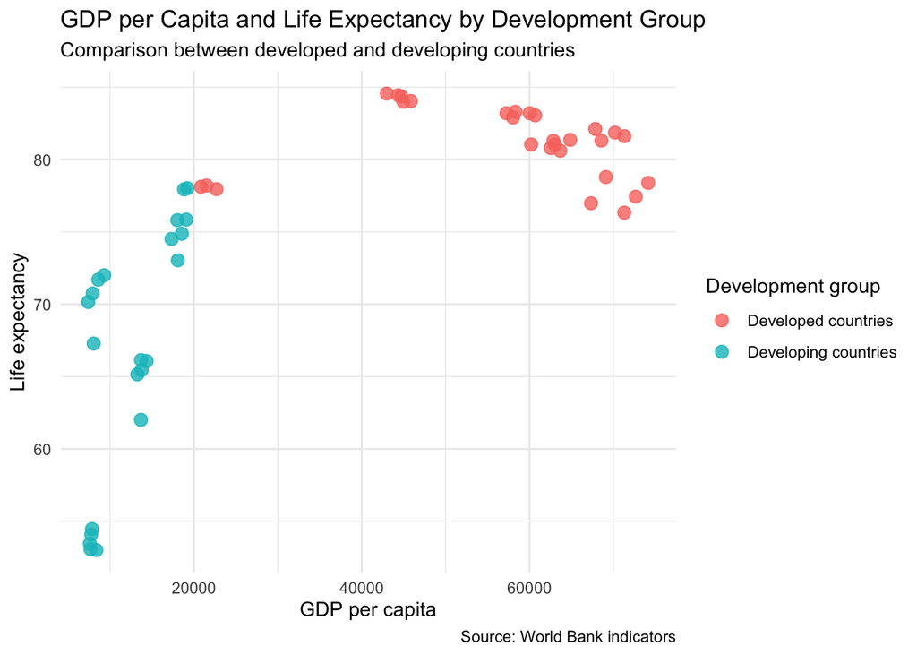

## 3.6 Event analysis

[figure not shown]

# Part 4 - Discussion

## 4.1 Discuss your findings

The results of this analysis show a clear relationship between GDP per capita and life expectancy across the ten selected countries between 2019 and 2023. Countries with higher GDP per capita generally demonstrated higher life expectancy, suggesting that stronger economies are associated with better healthcare systems, living conditions, and overall population health. The temporal analysis also showed a decline in average life expectancy between 2019 and 2021, followed by a recovery by 2023, which may reflect the global impact of the COVID-19 pandemic. In addition, the comparison between developed and developing countries highlighted persistent inequalities, indicating that economic development remains an important factor in explaining differences in health outcomes, although other external factors can also influence population well-being.

# Part 5 - Reproducibility

## 5.1 Github repository link

Provide the link to your PUBLIC repository here: https://github.com/Brian921013/Group-6-assignment

## 5.2 Reference list

Cutler, D., Deaton, A., & Lleras-Muney, A. (2006). The determinants of mortality. Journal of Economic Perspectives, 20(3), 97–120. https://doi.org/10.1257/jep.20.3.97

Deaton, A. (2003). Health, inequality, and economic development. Journal of Economic Literature, 41(1), 113–158. https://doi.org/10.1257/002205103321544710

Preston, S. H. (1975). The changing relation between mortality and level of economic development. Population Studies, 29(2), 231–248. https://doi.org/10.1080/00324728.1975.10410201

Schöley, J., Aburto, J. M., Kashnitsky, I., Kniffka, M. S., Zhang, L., Jaadla, H., Dowd, J. B., & Kashyap, R. (2022). Life expectancy changes since COVID-19. Nature Human Behaviour, 6, 1649–1659. https://doi.org/10.1038/s41562-022-01450-3

Global Life Expectancy Declines for First Time in 30 Years | Think Global Health. (2024). Council on Foreign Relations. https://www.thinkglobalhealth.org/article/global-life-expectancy-declines-first-time-30-years

Wieland, V. (2022). Overview of how major economies have responded to the Covid-19 pandemic. https://www.europarl.europa.eu/RegData/etudes/STUD/2022/689450/IPOL_STU(2022)689450_EN.pdf

World Health Organization. (2023). World health statistics 2023: Monitoring health for the SDGs. https://www.who.int/publications/i/item/9789240074323